# Об анализе зависимостей

Независимость случайных величин:
$$\displaystyle{{p_{\xi,\eta}(x, y_0)}\over{p_{\eta}(y_0)}} = p_\xi(x),$$
при таких $y_0$, что $p_{\eta}(y_0) ≠ 0$.

Для рассмотрения видов зависимости понадобится *функция условного математического ожидания*:
$$\phi(x) = \mathbf{E}\{\eta | \xi = x\},
\label{def1:ref}$$
где $\mathbf{E}\{\eta | \xi = x\} = \min_{\hat\eta \in \{\varphi(\xi)\}}\mathbf{E}(\eta - \hat\eta)^2$

В зависимости от вида функции условного математического ожидания (линейная, степенная и т.д.) и называется зависимость.

Линейная зависимость измеряется коэффициентом корреляции Пирсона:
$$\rho = \displaystyle{{cov(\xi,\eta)}\over{\sqrt{\mathbf{D}\xi}\sqrt{\mathbf{D}\eta}}},$$
где $cov(\xi,\eta) = \mathbf{E}\{(\xi - \mathbf{E}\xi)(\eta - \mathbf{E}\eta)\}$

Помимо коэффициента корреляции Пирсона, сущесвтует коэффициент корреляции Спирмена:
$$\rho_{S} = \rho(\mathrm{cdf}_{\xi}(\xi), \mathrm{cdf}_\eta(\eta)),$$

где $\mathrm{cdf}_{\xi}(\xi)$ — это функция распределения $\xi$ (сокращение от *cumulative distribution function*)

|  | X | minority | age | gender | credits | beauty | eval | division | native | tenure | students | allstudents | prof |
| --- | --- | --- | --- | --- | --- | --- | --- | --- | --- | --- | --- | --- | --- |
| 1 | 1 | yes | 36 | female | more | 0.2899157 | 4.3 | upper | yes | yes | 24 | 43 | 1 |
| 2 | 2 | no | 59 | male | more | -0.7377322 | 4.5 | upper | yes | yes | 17 | 20 | 2 |
| 3 | 3 | no | 51 | male | more | -0.5719836 | 3.7 | upper | yes | yes | 55 | 55 | 3 |
| 4 | 4 | no | 40 | female | more | -0.6779634 | 4.3 | upper | yes | yes | 40 | 46 | 4 |
| 5 | 5 | no | 31 | female | more | 1.5097940 | 4.4 | upper | yes | yes | 42 | 48 | 5 |
| 6 | 6 | no | 62 | male | more | 0.5885687 | 4.2 | upper | yes | yes | 182 | 282 | 6 |

В этом наборе данных есть 13 переменных:

1. X — идентификатор курса;
2. minority — принадлежит ли преподаватель к меньшинству;
3. age — возраст преподавателя;
4. gender — пол преподавателя;
5. credits — является ли предмет факультативным;
6. beauty — оценка физического облика преподавателя группой из шести студентов, усредненная по шести участникам оценки, нормированная;
7. eval — оценка преподавания курса от 1 (очень плохо) до 5 (отлично);
8. division — является ли этот курс курсом высшего или низшего отделения (Курсы низшего отделения — это в основном большие курсы первокурсников и второкурсников);
9. native — является ли преподаватель носителем английского языка;
10. tenure — имеет ли преподаватель учёную степень;
11. students — количетсво студентов, участвовавших в оценке;
12. allstudents — общее количетсво студентов, обучавшихся на этом курсе;
13. prof — идентификатор преподавателя;

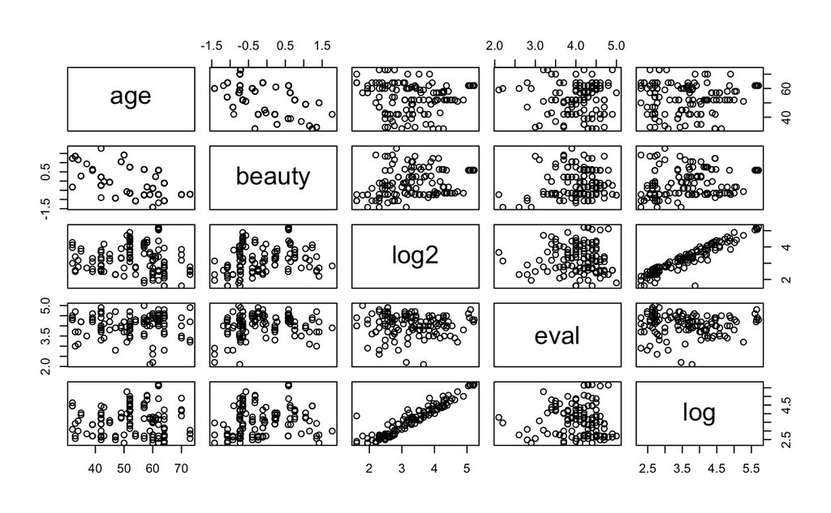

Похоже, что *age* и *beauty* имеют линейную зависимость. Проверим. Посчитаем коэффициент корреляции, а заодно и оценим его статистическую значимость:

```
    Pearson's product-moment correlation

data:  subset_data$age and subset_data$beauty
t = -6.3661, df = 125, p-value = 3.355e-09
alternative hypothesis: true correlation is not equal to 0
95 percent confidence interval:
 -0.6159321 -0.3508424
sample estimates:
       cor
-0.4948131
```

Гипотиза о том, что коэффициент корреляции Пирсона равен нулю отвергается. Оценка этого коэффициента **-0.4948131**. Проверим, для сравнения, коэффициент корреляции между количеством студентов, проголосовавших в опросе и посетивших курс:

```
    Pearson's product-moment correlation

data:  subset_data$log2 and subset_data$log
t = 32.482, df = 125, p-value < 2.2e-16
alternative hypothesis: true correlation is not equal to 0
95 percent confidence interval:
 0.9234612 0.9613986
sample estimates:
      cor
0.9455546
```

Гипотиза о том, что коэффициент корреляции Пирсона равен нулю отвергается. Оценка этого коэффициента **0.9455546**. Это вполне согласуется с тем, что видно на графике. В нашем случае пропусков в данных нет, однако если бы они были, то нужно было бы применить одну из двух техник борьбы с ними:

- Удалить всю строку с пропуском (casewise) и анализировать индивидуумы с заполненными нужными полями
- Рассматривать заполненные поля при рассчёте корреляции (индивидуумы могут быть разными) В первом случае есть риск получить выборку слишком маленького размера, а во втором корреляция получается рассчитана на разных данных, возможно влияние какого-то третьего признака.